# iPhone Purchase Prediction Analysis

This notebook performs Exploratory Data Analysis (EDA) and builds a Decision Tree model to predict iPhone purchases based on Gender, Age, and Salary.

## 1. Import Libraries

Loading necessary Python libraries for data analysis, visualization, and modeling.

```python
import pandas as pd
import numpy as np
import matplotlib.pyplot as plt
import seaborn as sns
from sklearn.model_selection import train_test_split, cross_val_score
from sklearn.preprocessing import StandardScaler
from sklearn.tree import DecisionTreeClassifier
from sklearn.metrics import confusion_matrix, classification_report, accuracy_score
from sklearn.compose import ColumnTransformer
from sklearn.preprocessing import OneHotEncoder
import warnings
warnings.filterwarnings('ignore')
%matplotlib inline
```

## 2. Load and Inspect Data

Reading the CSV file and displaying basic information about the dataset.

```python
# Load the dataset
df = pd.read_csv('iphone_purchase_records.csv')

# Display first few rows
print("First 5 rows of the dataset:")
print(df.head())

# Display dataset info
print("\nDataset Info:")
print(df.info())

# Check for missing values
print("\nMissing Values:")
print(df.isnull().sum())

# Summary statistics
print("\nSummary Statistics:")
print(df.describe())
```

```
First 5 rows of the dataset:
   Gender  Age  Salary  Purchase Iphone
0    Male   19   19000                0
1    Male   35   20000                0
2  Female   26   43000                0
3  Female   27   57000                0
4    Male   19   76000                0

Dataset Info:
<class 'pandas.core.frame.DataFrame'>
RangeIndex: 400 entries, 0 to 399
Data columns (total 4 columns):
 #   Column           Non-Null Count  Dtype
---  ------           --------------  -----
 0   Gender           400 non-null    object
 1   Age              400 non-null    int64
 2   Salary           400 non-null    int64
 3   Purchase Iphone  400 non-null    int64
dtypes: int64(3), object(1)
memory usage: 12.6+ KB
None

Missing Values:
Gender             0
Age                0
Salary             0
Purchase Iphone    0
dtype: int64

Summary Statistics:
              Age         Salary  Purchase Iphone
count  400.000000     400.000000       400.000000
mean    37.655000   69742.500000         0.357500
std     10.482877   34096.960282         0.479864
min     18.000000   15000.000000         0.000000
25%     29.750000   43000.000000         0.000000
50%     37.000000   70000.000000         0.000000
75%     46.000000   88000.000000         1.000000
max     60.000000  150000.000000         1.000000
```

## 3. Exploratory Data Analysis (EDA)

Analyzing the distribution of features and their relationship with the target variable.

### 3.1. Distribution of Purchase iPhone

Visualizing the distribution of the target variable to check for class imbalance.

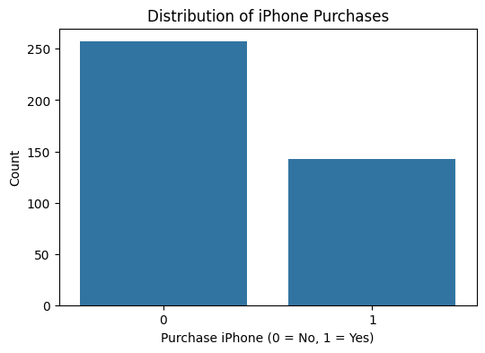

```python
plt.figure(figsize=(6, 4))
sns.countplot(x='Purchase Iphone', data=df)
plt.title('Distribution of iPhone Purchases')
plt.xlabel('Purchase iPhone (0 = No, 1 = Yes)')
plt.ylabel('Count')
plt.show()
```

### 3.2. Gender Distribution

Examining the distribution of Gender and its relation to purchases.

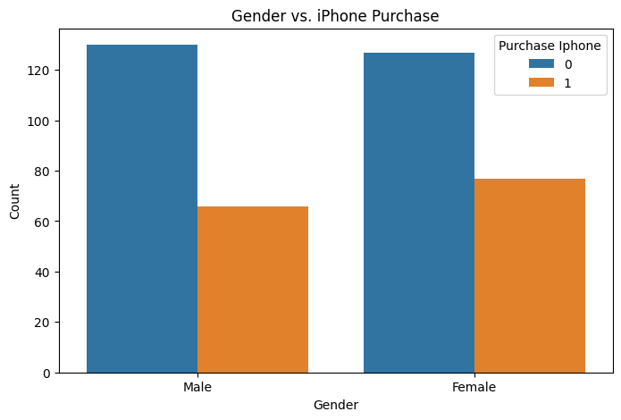

```python
plt.figure(figsize=(8, 5))
sns.countplot(x='Gender', hue='Purchase Iphone', data=df)
plt.title('Gender vs. iPhone Purchase')
plt.xlabel('Gender')
plt.ylabel('Count')
plt.show()
```

### 3.3. Age and Salary Distributions

Visualizing the distribution of Age and Salary, segmented by Purchase iPhone.

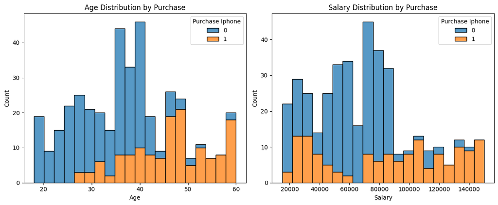

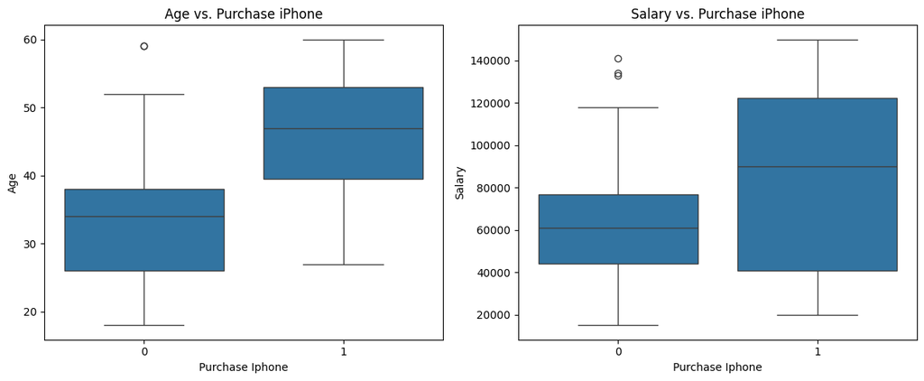

```python
# Age distribution
plt.figure(figsize=(12, 5))
plt.subplot(1, 2, 1)
sns.histplot(data=df, x='Age', hue='Purchase Iphone', multiple='stack', bins=20)
plt.title('Age Distribution by Purchase')

# Salary distribution
plt.subplot(1, 2, 2)
sns.histplot(data=df, x='Salary', hue='Purchase Iphone', multiple='stack', bins=20)
plt.title('Salary Distribution by Purchase')
plt.tight_layout()
plt.show()

# Box plots
plt.figure(figsize=(12, 5))
plt.subplot(1, 2, 1)
sns.boxplot(x='Purchase Iphone', y='Age', data=df)
plt.title('Age vs. Purchase iPhone')

plt.subplot(1, 2, 2)
sns.boxplot(x='Purchase Iphone', y='Salary', data=df)
plt.title('Salary vs. Purchase iPhone')
plt.tight_layout()
plt.show()
```

### 3.4. Scatter Plot: Age vs. Salary

Visualizing the relationship between Age and Salary, colored by Purchase iPhone.

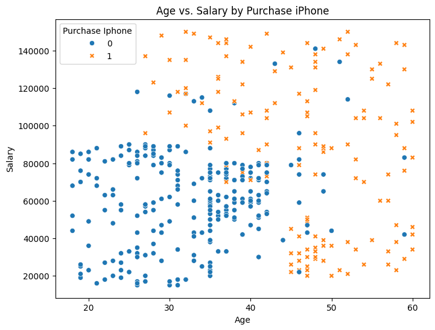

```python
plt.figure(figsize=(8, 6))
sns.scatterplot(x='Age', y='Salary', hue='Purchase Iphone', style='Purchase Iphone', data=df)
plt.title('Age vs. Salary by Purchase iPhone')
plt.show()
```

### 3.5. Correlation Analysis

Checking correlations between numerical features (Age, Salary).

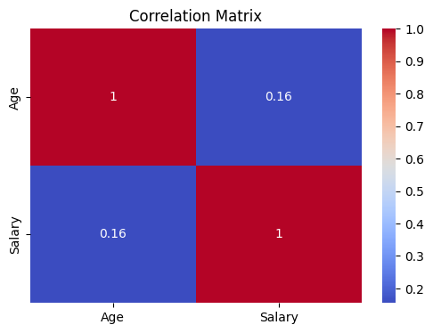

```python
# Correlation matrix (excluding Gender as it's categorical)
plt.figure(figsize=(6, 4))
sns.heatmap(df[['Age', 'Salary']].corr(), annot=True, cmap='coolwarm')
plt.title('Correlation Matrix')
plt.show()
```

## 4. Data Preprocessing

Preparing the data for modeling by encoding categorical variables and scaling numerical features.

```python
# Define features and target
X = df[['Gender', 'Age', 'Salary']]
y = df['Purchase Iphone']

# One-Hot Encoding for Gender
column_transformer = ColumnTransformer(
    transformers=[
        ('encoder', OneHotEncoder(drop='first'), ['Gender'])
    ],
    remainder='passthrough'
)
X_encoded = column_transformer.fit_transform(X)

# Scale numerical features
scaler = StandardScaler()
X_scaled = scaler.fit_transform(X_encoded)

# Split data into training and testing sets
X_train, X_test, y_train, y_test = train_test_split(X_scaled, y, test_size=0.2, random_state=42)

print("Training set shape:", X_train.shape)
print("Testing set shape:", X_test.shape)
```

```
Training set shape: (320, 3)
Testing set shape: (80, 3)
```

## 5. Build and Train Decision Tree Model

Training a Decision Tree classifier with tuned hyperparameters.

```python
# Initialize and train the model
dt_model = DecisionTreeClassifier(max_depth=5, min_samples_split=10, random_state=42)
dt_model.fit(X_train, y_train)

# Perform 5-fold cross-validation
cv_scores = cross_val_score(dt_model, X_train, y_train, cv=5)
print("Cross-Validation Scores:", cv_scores)
print("Mean CV Score:", cv_scores.mean())
```

```
Cross-Validation Scores: [0.90625  0.953125 0.875    0.828125 0.890625]
Mean CV Score: 0.890625
```

## 6. Model Evaluation

Evaluating the model using accuracy, confusion matrix, and classification report.

```
Test Set Accuracy: 0.875
```

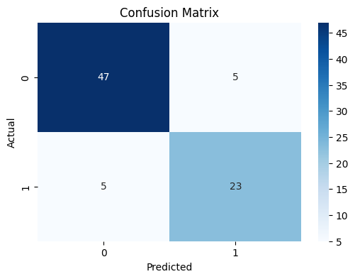

```
Classification Report:
```

```
              precision    recall  f1-score   support

           0       0.90      0.90      0.90        52
           1       0.82      0.82      0.82        28

    accuracy                           0.88        80
   macro avg       0.86      0.86      0.86        80
weighted avg       0.88      0.88      0.88        80
```

```python
# Predict on test set
y_pred = dt_model.predict(X_test)

# Accuracy
accuracy = accuracy_score(y_test, y_pred)
print("Test Set Accuracy:", accuracy)

# Confusion Matrix
cm = confusion_matrix(y_test, y_pred)
plt.figure(figsize=(6, 4))
sns.heatmap(cm, annot=True, fmt='d', cmap='Blues')
plt.title('Confusion Matrix')
plt.xlabel('Predicted')
plt.ylabel('Actual')
plt.show()

# Classification Report
print("\nClassification Report:")
print(classification_report(y_test, y_pred))
```

## 7. Feature Importance

Visualizing the importance of each feature in the Decision Tree.

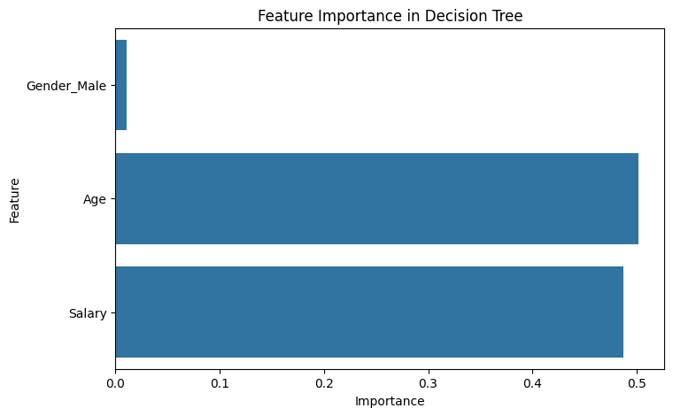

```python
# Feature names after encoding
feature_names = ['Gender_Male'] + ['Age', 'Salary']

# Plot feature importance
plt.figure(figsize=(8, 5))
sns.barplot(x=dt_model.feature_importances_, y=feature_names)
plt.title('Feature Importance in Decision Tree')
plt.xlabel('Importance')
plt.ylabel('Feature')
plt.show()
```

## 8. Visualize Decision Tree

Visualizing the Decision Tree structure (text-based; graphical visualization requires graphviz).

```python
from sklearn.tree import export_text
# Text-based tree
tree_rules = export_text(dt_model, feature_names=feature_names)
print("Decision Tree Rules:\n", tree_rules)

# Optional: Graphical tree (uncomment if graphviz is installed)
# from sklearn.tree import plot_tree
# plt.figure(figsize=(15, 10))
# plot_tree(dt_model, feature_names=feature_names, class_names=['No', 'Yes'], filled=True)
# plt.title('Decision Tree Visualization')
# plt.show()
```

```
Decision Tree Rules:
 |--- Age <= 0.65
|   |--- Salary <= 0.61
|   |   |--- Age <= -0.11
|   |   |   |--- class: 0
|   |   |--- Age >  -0.11
|   |   |   |--- Salary <= 0.40
|   |   |   |   |--- Salary <= -0.07
|   |   |   |   |   |--- class: 0
|   |   |   |   |--- Salary >  -0.07
|   |   |   |   |   |--- class: 0
|   |   |   |--- Salary >  0.40
|   |   |   |   |--- class: 1
|   |--- Salary >  0.61
|   |   |--- Salary <= 1.87
|   |   |   |--- Salary <= 1.80
|   |   |   |   |--- Salary <= 1.18
|   |   |   |   |   |--- class: 1
|   |   |   |   |--- Salary >  1.18
|   |   |   |   |   |--- class: 1
|   |   |   |--- Salary >  1.80
|   |   |   |   |--- class: 0
|   |   |--- Salary >  1.87
|   |   |   |--- class: 1
|--- Age >  0.65
|   |--- Salary <= -0.86
|   |   |--- class: 1
|   |--- Salary >  -0.86
|   |   |--- Salary <= 0.43
|   |   |   |--- Age <= 1.32
|   |   |   |   |--- Age <= 1.04
|   |   |   |   |   |--- class: 1
|   |   |   |   |--- Age >  1.04
|   |   |   |   |   |--- class: 0
|   |   |   |--- Age >  1.32
|   |   |   |   |--- Gender_Male <= 0.02
|   |   |   |   |   |--- class: 0
|   |   |   |   |--- Gender_Male >  0.02
|   |   |   |   |   |--- class: 1
|   |   |--- Salary >  0.43
|   |   |   |--- Age <= 1.42
|   |   |   |   |--- Age <= 1.23
|   |   |   |   |   |--- class: 1
|   |   |   |   |--- Age >  1.23
|   |   |   |   |   |--- class: 0
|   |   |   |--- Age >  1.42
|   |   |   |   |--- class: 1
```

## 9. Conclusion

Based on the EDA, Age and Salary are key predictors of iPhone purchases, with older individuals and those with higher salaries more likely to purchase. Gender has a lesser impact. The Decision Tree model achieves reasonable accuracy, but performance could be improved with additional features or ensemble methods like Random Forest. The model is interpretable, as shown by the feature importance and tree structure.